# 03_Predicciones_semanales

### Técnicas de Predicción: series temporales

Alba Rodríguez Berenguel

En este notebook voy a realizar pruebas con distintos modelos **semanales**, con el objetivo de comparar los resultados que me devuelvan y escoger el modelo que sea más preciso para realizar las predicciones futuras.

Los modelos que voy a utilizar son: ETS, ARIMA y THETA, empleando los datos que modifiqué rellenando los 0.

**En este caso he decidido no incluir el modelo PROPHET, ya que a pesar de que con los datos diarios devolvió resultados muy buenos, al hacerlo con los semanales obtenía un r2 negativo, por lo que no era óptimo.**

La estructura que voy a seguir es la siguiente:

1. Carga de los datos.
2. Modelo ETS.
3. Modelo ARIMA
4. Modelo THETA.
5. Predicciones.
6. Exportación de los datos.

```python
# Librerias.
import pandas as pd
import numpy as np
from sktime.utils.plotting import plot_series
from sktime.forecasting.model_selection import temporal_train_test_split
from sktime.forecasting.ets import AutoETS
from sktime.performance_metrics.forecasting import MeanSquaredError
from sktime.performance_metrics.forecasting import MeanAbsolutePercentageError
from sktime.performance_metrics.forecasting import mean_absolute_percentage_error
from sktime.forecasting.exp_smoothing import ExponentialSmoothing
from sktime.forecasting.naive import NaiveForecaster
from sktime.forecasting.model_selection import ExpandingWindowSplitter
from sktime.forecasting.model_selection import ForecastingGridSearchCV
from sktime.forecasting.compose import TransformedTargetForecaster
from sktime.transformations.series.boxcox import LogTransformer
from sktime.forecasting.statsforecast import StatsForecastAutoARIMA
from sktime.forecasting.theta import ThetaForecaster
from sktime.forecasting.tbats import TBATS
from sklearn.metrics import r2_score
from prophet import Prophet
import matplotlib.pyplot as plt
import warnings
warnings.filterwarnings('ignore')
```

## 1. Carga de los datos.

Para estos modelos voy a hacer una pequeña modificación a los datos. Dado que los tengo que agrupar por semanas, voy a sustituir los días que son domingos por 0, para que no incremente falsamente las ventas.

No uso los datos originales porque no solo he modificado valores 0 que son domingos, también había 0 en semanas e incluso meses, en los que algunas de las tiendas habían estado cerradas.

```python
# Cargo el fichero que he preparado en el primer notebook.
sales_df = (pd.read_csv('../data/processed/sales_mod.csv')
            .assign(**{'Date': lambda df: pd.to_datetime(df['Date'])}))

# Añado una columna para ver qué dias son domingo.
sales_df['dias'] = sales_df['Date'].dt.weekday

# Donde sea domingo, que ponga 0 en las ventas.
sales_df['Sales'] = np.where(sales_df['dias'] == 6, 0, sales_df['Sales'])

#Elimino esa columna.
sales_df = sales_df.drop(['dias'], axis=1)

# Los paso a semanales.
sales_df_w = sales_df.set_index('Date').resample('W')['Sales'].sum().to_frame()

sales_df_w.head()
```

| Date | Sales |
| --- | --- |
| 2013-01-06 | 302633 |
| 2013-01-13 | 422382 |
| 2013-01-20 | 326543 |
| 2013-01-27 | 396852 |
| 2013-02-03 | 358102 |

## 2. Modelo ETS.

```python
# Transformo el df a formato SKTime.
sales_sk = sales_df_w.astype('float64').to_period('W')
sales_sk.head()
```

| Date | Sales |
| --- | --- |
| 2012-12-31/2013-01-06 | 302633.0 |
| 2013-01-07/2013-01-13 | 422382.0 |
| 2013-01-14/2013-01-20 | 326543.0 |
| 2013-01-21/2013-01-27 | 396852.0 |
| 2013-01-28/2013-02-03 | 358102.0 |

Tengo que dividir los datos en train y test, voy a establecer que el test sea el 10% de los datos.

```python
# Divido en train y test.
ts_train, ts_test = temporal_train_test_split(sales_sk, test_size=0.10)

# Compruebo el tamaño.
print("Train:",ts_train.shape)
print("Test:",ts_test.shape)
```

```
Train: (121, 1)
Test: (14, 1)
```

```python
# Defino el modelo.
ets_model = AutoETS(auto=True, n_jobs=-1, sp=52)

# Estimacion.
ets_model.fit(ts_train)

# Predicción.
fh_test=np.arange(1,len(ts_test)+1)
ets_pred = ets_model.predict(fh=fh_test)
ets_pred.head()
```

|  | Sales |
| --- | --- |
| 2015-04-27/2015-05-03 | 573501.119849 |
| 2015-05-04/2015-05-10 | 482886.835126 |
| 2015-05-11/2015-05-17 | 438039.313693 |
| 2015-05-18/2015-05-24 | 425758.481654 |
| 2015-05-25/2015-05-31 | 489697.384595 |

```
RMSE: 37624.38
MAPE: 5.38%
```

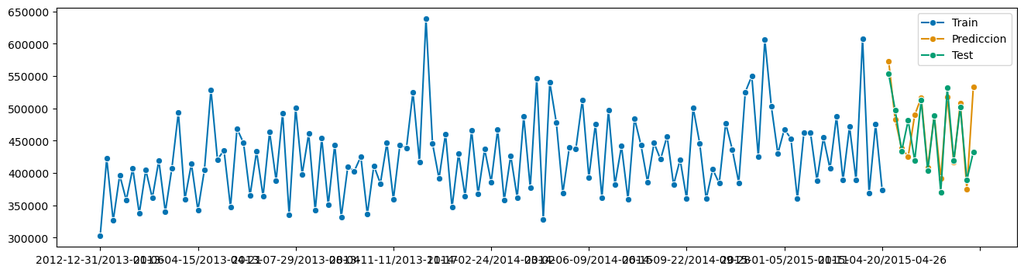

```python
# Grafico y evaluacion del modelo.
fig, ax = plot_series(ts_train, ets_pred, ts_test, labels=["Train", "Prediccion", "Test"])

RMSE = MeanSquaredError(square_root=True)
MAPE = MeanAbsolutePercentageError(symmetric=False)

def ForecastPerformance(original,forecast):
    print(f'RMSE: {round(RMSE(original, forecast),2)}')
    print(f'MAPE: {round(MAPE(original, forecast)*100,2)}%')

ForecastPerformance(ts_test, ets_pred)
```

#### Cross validation.

```python
# Inputs: transformaciones y modelos
pipe = TransformedTargetForecaster(steps=[
    ("forecaster", NaiveForecaster())])
# Defenir el CV
cv = ExpandingWindowSplitter(
    initial_window=60,
     step_length=1,
     start_with_window=True,
     fh=fh_test)
# definir los modelos y los parametros (GRID)
gscv = ForecastingGridSearchCV(
     forecaster=pipe,
    param_grid=[{
         "forecaster": [NaiveForecaster(sp=52)],
         "forecaster__strategy": ["drift", "last", "mean"],
     },
     {
          "forecaster": [ExponentialSmoothing(sp=52)],
          "forecaster__trend": ["add", "mul"],
          "forecaster__damped_trend": [True,False],
          "forecaster__seasonal": ["add", "mul"],
    },
     ],
     cv=cv,
     verbose=1,
     n_jobs=-1)
```

```python
# Estimo todos los modelos por CV
gscv.fit(ts_train)

# Resultados
gscv.cv_results_
```

```
Fitting 48 folds for each of 11 candidates, totalling 528 fits
```

|  | mean_test_MeanAbsolutePercentageError | mean_fit_time | mean_pred_time | params | rank_test_MeanAbsolutePercentageError |
| --- | --- | --- | --- | --- | --- |
| 0 | 0.170515 | 0.033229 | 0.013332 | {'forecaster': NaiveForecaster(sp=52, strategy... | 8.0 |
| 1 | 0.111353 | 0.032642 | 0.011402 | {'forecaster': NaiveForecaster(sp=52), 'foreca... | 6.0 |
| 2 | 0.118088 | 0.032398 | 0.012355 | {'forecaster': NaiveForecaster(sp=52, strategy... | 7.0 |
| 3 | 0.079412 | 0.297677 | 0.012747 | {'forecaster': ExponentialSmoothing(damped_tre... | 3.0 |
| 4 | 0.678667 | 0.462384 | 0.011521 | {'forecaster': ExponentialSmoothing(damped_tre... | 11.0 |
| 5 | 0.378524 | 0.305872 | 0.013423 | {'forecaster': ExponentialSmoothing(damped_tre... | 9.0 |
| 6 | 0.084620 | 0.509231 | 0.011798 | {'forecaster': ExponentialSmoothing(damped_tre... | 5.0 |
| 7 | 0.077548 | 0.293765 | 0.013597 | {'forecaster': ExponentialSmoothing(seasonal='... | 2.0 |
| 8 | 0.077412 | 0.194861 | 0.007507 | {'forecaster': ExponentialSmoothing(seasonal='... | 1.0 |
| 9 | 0.388456 | 0.193790 | 0.007871 | {'forecaster': ExponentialSmoothing(seasonal='... | 10.0 |
| 10 | 0.080965 | 0.186515 | 0.009417 | {'forecaster': ExponentialSmoothing(seasonal='... | 4.0 |

```python
# El mejor modelo.
print(gscv.best_forecaster_)

# El performance del mejor modelo
print(gscv.best_score_)
```

```
TransformedTargetForecaster(steps=[('forecaster',
                                    ExponentialSmoothing(seasonal='add', sp=52,
                                                         trend='mul'))])
0.07741237046505349
```

```python
# Predicción
ets_cv_pred = gscv.predict(fh=fh_test)
ets_cv_pred.head()
```

|  | Sales |
| --- | --- |
| 2015-04-27/2015-05-03 | 564710.692053 |
| 2015-05-04/2015-05-10 | 501474.306277 |
| 2015-05-11/2015-05-17 | 396089.798215 |
| 2015-05-18/2015-05-24 | 461435.221173 |
| 2015-05-25/2015-05-31 | 463930.450844 |

```
RMSE: 37392.73
MAPE: 5.95%
None
```

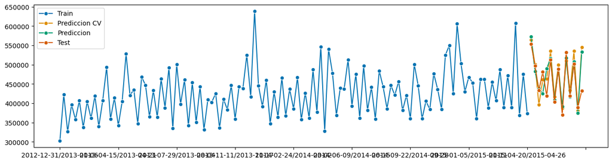

```python
# Grafico y evaluacion del modelo.
fig, ax = plot_series(ts_train, ets_cv_pred, ets_pred, ts_test, labels=["Train", "Prediccion CV", "Prediccion", "Test"])

print(ForecastPerformance(ts_test, ets_cv_pred))
```

## 3. Modelo ARIMA.

```python
# Realizo la transformación logaritmica.
transformer = LogTransformer()
log_sales= transformer.fit_transform(sales_sk)
log_sales.tail()
```

| Date | Sales |
| --- | --- |
| 2015-06-29/2015-07-05 | 13.184058 |
| 2015-07-06/2015-07-12 | 12.946964 |
| 2015-07-13/2015-07-19 | 13.125776 |
| 2015-07-20/2015-07-26 | 12.872624 |
| 2015-07-27/2015-08-02 | 12.977261 |

```python
# Divido en train y test.
log_ts_train, log_ts_test = temporal_train_test_split(y = log_sales, test_size=0.1)

# Definimos el modelo.
arima_model = StatsForecastAutoARIMA(sp=52)

# Estimacion.
arima_model.fit(log_ts_train)
```

```
StatsForecastAutoARIMA(sp=52)
```

```python
# Predicción.
fh_test=np.arange(1,len(ts_test)+1)
log_arima_pred = arima_model.predict(fh=fh_test)

# Prediccion niveles.
arima_pred=np.exp(log_arima_pred)
arima_pred.head()
```

|  | Sales |
| --- | --- |
| 2015-04-27/2015-05-03 | 513558.361283 |
| 2015-05-04/2015-05-10 | 487660.433948 |
| 2015-05-11/2015-05-17 | 366426.729818 |
| 2015-05-18/2015-05-24 | 440914.700839 |
| 2015-05-25/2015-05-31 | 437241.111993 |

```
RMSE: 36226.34
MAPE: 6.59%
```

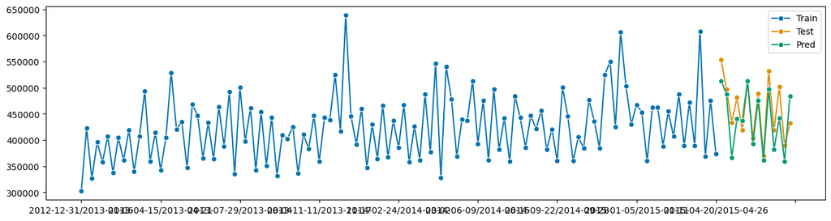

```python
#Grafico y evaluacion del modelo.
fig, ax = plot_series(ts_train, ts_test, arima_pred, labels=["Train", "Test", "Pred"])

ForecastPerformance(ts_test, arima_pred)
```

## 4. Modelo Theta.

```python
# Definimos el modelo.
theta_model = ThetaForecaster(sp=52)

# Estimacion.
theta_model.fit(ts_train)
```

```
ThetaForecaster(sp=52)
```

```python
theta_model.get_fitted_params()
```

```
{'initial_level': 370584.8333600913, 'smoothing_level': 0.08558139534883721}
```

```python
# Predicción.
fh_test=np.arange(1,len(ts_test)+1)
theta_pred = theta_model.predict(fh=fh_test)
theta_pred
```

|  | Sales |
| --- | --- |
| 2015-04-27/2015-05-03 | 572627.724601 |
| 2015-05-04/2015-05-10 | 506929.605205 |
| 2015-05-11/2015-05-17 | 390626.830800 |
| 2015-05-18/2015-05-24 | 465170.349946 |
| 2015-05-25/2015-05-31 | 463123.034669 |
| 2015-06-01/2015-06-07 | 541967.455831 |
| 2015-06-08/2015-06-14 | 415470.879119 |
| 2015-06-15/2015-06-21 | 502462.193501 |
| 2015-06-22/2015-06-28 | 382536.214878 |
| 2015-06-29/2015-07-05 | 519502.481135 |
| 2015-07-06/2015-07-12 | 416889.368640 |
| 2015-07-13/2015-07-19 | 504812.351388 |
| 2015-07-20/2015-07-26 | 374640.180779 |
| 2015-07-27/2015-08-02 | 531591.118781 |

```
RMSE: 33859.22
MAPE: 5.29%
```

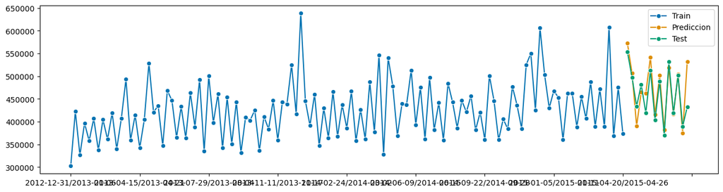

```python
#Grafico y evaluacion del modelo.
fig, ax = plot_series(ts_train, theta_pred, ts_test, labels=["Train", "Prediccion", "Test"])

ForecastPerformance(ts_test, theta_pred)
```

## 5. Predicciones.

Para estos modelos semanales, el que mejor resultado ha devuelto es el modelo THETA que posee el MAPE más bajo con un 5,29%, por lo tanto, es el que voy a emplear para las predicciones.

Lo que haré es emplear el mismo modelo, pero entrenándolo con la totalidad de los datos.

```python
# Definimos el modelo.
theta_model_final = ThetaForecaster(sp=52)

# Estimacion.
theta_model_final.fit(sales_sk)
```

```
ThetaForecaster(sp=52)
```

```python
theta_model_final.get_fitted_params()
```

```
{'initial_level': 362301.6392393863, 'smoothing_level': 0.09709302325581395}
```

```python
# Predicción
fh_pred=np.arange(1, 7)
theta_final = theta_model_final.predict(fh=fh_pred)
theta_final
```

|  | Sales |
| --- | --- |
| 2015-08-03/2015-08-09 | 442753.534624 |
| 2015-08-10/2015-08-16 | 447104.663956 |
| 2015-08-17/2015-08-23 | 413648.010535 |
| 2015-08-24/2015-08-30 | 460536.707236 |
| 2015-08-31/2015-09-06 | 423331.949048 |
| 2015-09-07/2015-09-13 | 434234.870468 |

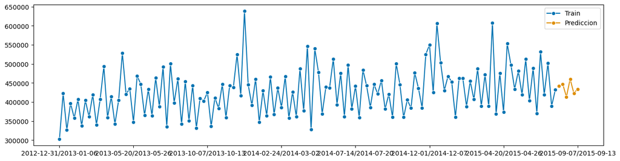

```python
fig, ax = plot_series(sales_sk, theta_final, labels=["Train", "Prediccion"])
```

Las predicciones que nos ha devuelto el modelo son algo más bajas que los datos previos, pero también hay que tener en cuenta que son meses de verano, durante los que las ventas disminuían significativamente.

Por último, exporto las predicciones en un csv. Se encontrará en la carpeta predicciones de este trabajo.

```python
# Guardo en la variable unicamente la columna de ventas.
pred_val = theta_final['Sales']

# Exporto a csv, estableciendo que no se guarde ni el índice, ni la cabecera, ya que solo quiero las predicciones.
pred_val.to_csv('../predicciones/pred_semanales.csv', index=False, header=False)
```